# ch8 applied

S Zimine

# Ex 7

```r
require(MASS)
require(randomForest)
data(Boston)
nfeats <- dim(Boston)[2] -1 #total number of features in the dataset
nsamp <-  dim(Boston)[1]

mtrys <- c(nfeats, nfeats/2, sqrt(nfeats))
ntrees <- seq(from=1, to=500)
```

We define features train and test sets and train and test response vectors

```r
set.seed(1101)
#split into train and test
#train <- sample( 1:nsamp, floor(4/5 * nsamp) )
train <- sample( 1:nsamp, nsamp/2 )
test <- (1:nsamp)[-train]

X.train <- Boston[train, -14] # all features minus response
X.test <-  Boston[test, -14]

Y.train <- Boston[train, 14] #response vector
Y.test  <- Boston[test, 14]
```

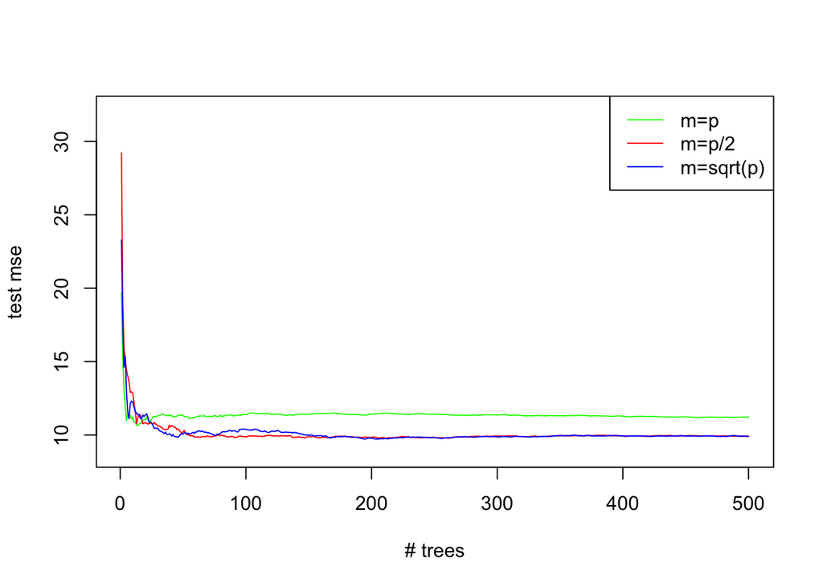

```r
p <- nfeats
p.2 <- p / 2
p.sq <- sqrt(p)

#fit models for each  p (rf.boston.p$mse will contain values for each tree between 1 and 500)
rf.boston.p <- randomForest(X.train, Y.train, xtest=X.test, ytest=Y.test, mtry=p, ntree=500)
rf.boston.p2 <- randomForest(X.train, Y.train, xtest=X.test, ytest=Y.test, mtry=p.2, ntree=500)
rf.boston.psq <- randomForest(X.train, Y.train, xtest=X.test, ytest=Y.test, mtry=p.sq, ntree=500)

# and plot the tes tmse data
# find ylims
y_min <- 0.9* min(c(rf.boston.p$test$mse, rf.boston.p2$test$mse, rf.boston.psq$test$mse))
y_max <- 1.1* max(c(rf.boston.p$test$mse, rf.boston.p2$test$mse, rf.boston.psq$test$mse))

plot(1:500, rf.boston.p$test$mse, col="green", type="l", xlab="# trees", ylab="test mse", ylim=c(y_min,y_max))
lines(1:500, rf.boston.p2$test$mse, col="red", type="l")
lines(1:500, rf.boston.psq$test$mse, col="blue", type="l")
legend("topright", c("m=p", "m=p/2", "m=sqrt(p)"), col=c("green", "red", "blue"), cex=1, lty=1)
```

If we use another split between train and test , we can different test mse values . For instance for 4/5, 1/5 split the test mse would be around 6.

# Ex 8

```r
require(ISLR)
require(tree)
data(Carseats)
```

### a)

```r
set.seed(1011)
nfeats <- dim(Carseats)[2] -1
nsamp <-  dim(Carseats)[1]
train <- sample( 1:nsamp, size=250) #250 / 150 split
test <- (1:nsamp)[-train]
```

### b)

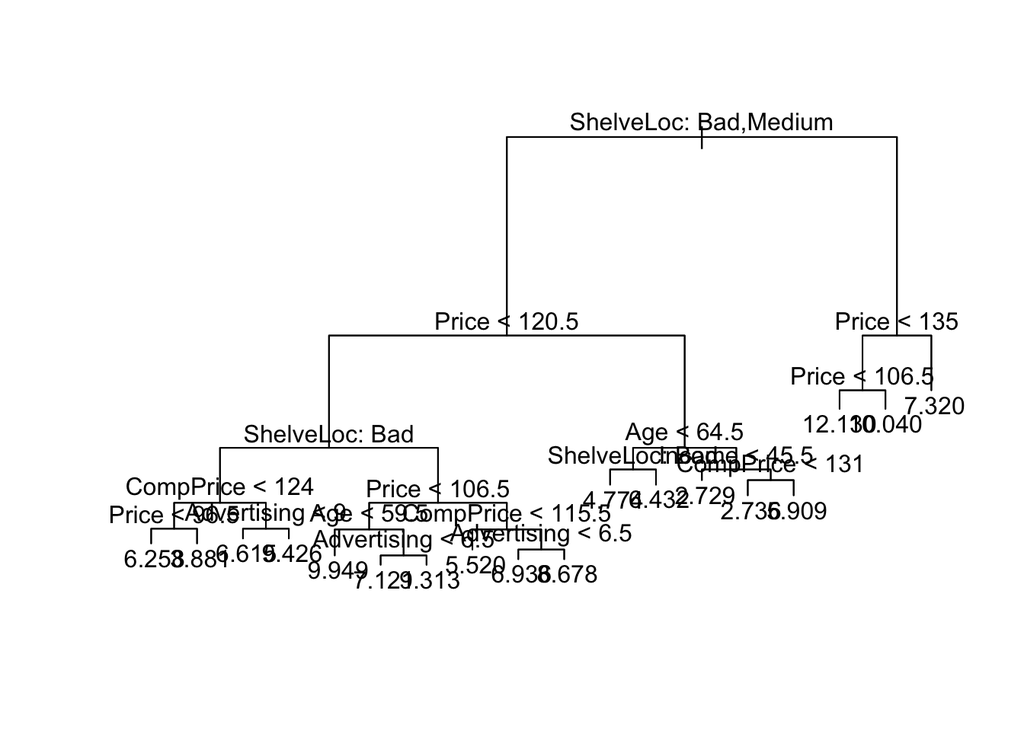

```r
tree.carseats <- tree(Sales~., data=Carseats[train,])
plot(tree.carseats)
text(tree.carseats,pretty=0)
```

```r
tree.pred <- predict(tree.carseats, Carseats[test,])
test.mse <- mean( (Carseats[test,]$Sales - tree.pred)^2 )
print(paste("full tree test mse", test.mse))
```

```
## [1] "full tree test mse 4.71690559790065"
```

### c

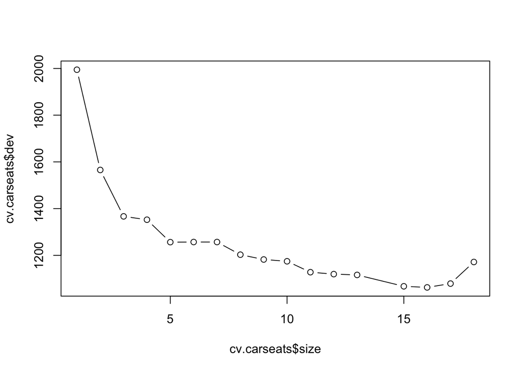

```r
cv.carseats <- cv.tree(tree.carseats, FUN=prune.tree)
plot(cv.carseats$size, cv.carseats$dev, type="b") #best value at 16
```

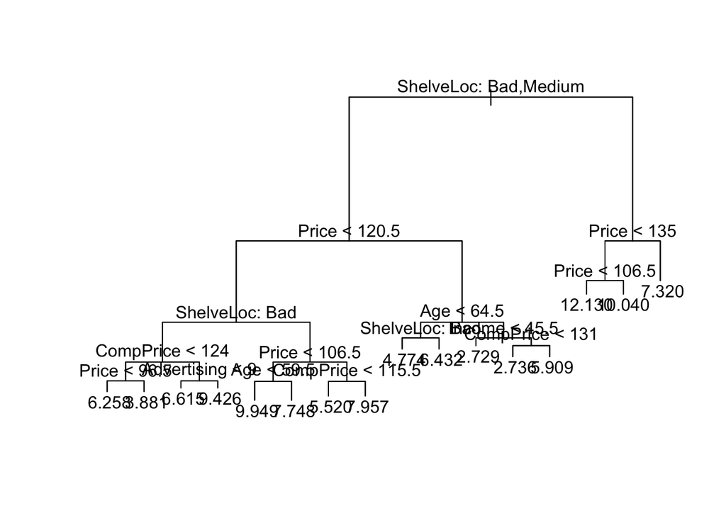

```r
prune.carseats <- prune.tree(tree.carseats, best=16)
plot(prune.carseats)
text(prune.carseats,pretty=0)
```

```r
tree.pred <- predict(prune.carseats, Carseats[test,])
test.mse <- mean( (Carseats[test,]$Sales - tree.pred)^2 )
print(paste("pruned tree test mse", test.mse))
```

```
## [1] "pruned tree test mse 4.6768927317281"
```

Prunning did a tiny improvement of the test mse

#### d)

```r
require(randomForest)
bag.carseats <- randomForest(Sales~.,data=Carseats[train,], mtry=nfeats, tree=500, importance=T) #m=p is a bagging case of RandomForest
bag.pred <- predict(bag.carseats, Carseats[test,])
test.mse <- mean( (Carseats[test,]$Sales - bag.pred)^2 )
print(paste("bagging test mse", test.mse))
```

```
## [1] "bagging test mse 2.76579249706974"
```

```r
print( importance(bag.carseats))
```

```
##                %IncMSE IncNodePurity
## CompPrice   22.3762937     150.89532
## Income       8.1781207      98.37810
## Advertising 18.8561904     136.65028
## Population  -1.0147991      57.07011
## Price       62.5246421     581.44714
## ShelveLoc   68.3464106     577.28853
## Age         23.8895403     220.13366
## Education    1.1538107      48.16614
## Urban       -0.1043981      10.31345
## US           3.5729983      10.17892
```

Bagging reduces significantly the test mse.

The most significat featatures to predict $\tt{Sales}$ are: $\tt{Price}$, $\tt{ShelveLoc}$, $\tt{Age}$.

#### e)

```r
rf.carseats = randomForest(Sales~., data=Carseats[train,], mtry=5, ntree=500, importance=T)
rf.pred = predict(rf.carseats, Carseats[test,])
test.mse  = mean((Carseats[test,]$Sales - rf.pred)^2)
print( importance(rf.carseats) )
```

```
##                %IncMSE IncNodePurity
## CompPrice   14.0146237     147.55243
## Income       7.6672487     129.52525
## Advertising 16.0631447     169.95029
## Population  -2.2050812      82.04353
## Price       49.7651774     503.66565
## ShelveLoc   54.0201838     511.48883
## Age         20.5928703     242.11060
## Education    0.7681371      57.06154
## Urban       -0.4266211      12.83816
## US           3.1909625      15.86597
```

```r
print(paste("random forest test mse", test.mse))
```

```
## [1] "random forest test mse 2.9610512198521"
```

In this data set RF slightly increased the test mse

# Ex 9

### a

```r
set.seed(1013)
nfeats <- dim(OJ)[2] -1
nsamp <-  dim(OJ)[1]
train <- sample( 1:nsamp, size=800) #250 / 150 split
test <- (1:nsamp)[-train]
```

#### b

```r
tree.oj <- tree(Purchase~., data=OJ[train,] )
summary(tree.oj)
```

```
##
## Classification tree:
## tree(formula = Purchase ~ ., data = OJ[train, ])
## Variables actually used in tree construction:
## [1] "LoyalCH"   "PriceDiff"
## Number of terminal nodes:  7
## Residual mean deviance:  0.7517 = 596.1 / 793
## Misclassification error rate: 0.155 = 124 / 800
```

#### c

```r
print(tree.oj)
```

```
## node), split, n, deviance, yval, (yprob)
##       * denotes terminal node
##
##  1) root 800 1075.00 CH ( 0.60250 0.39750 )
##    2) LoyalCH < 0.5036 359  422.80 MM ( 0.27577 0.72423 )
##      4) LoyalCH < 0.276142 170  119.10 MM ( 0.11176 0.88824 ) *
##      5) LoyalCH > 0.276142 189  257.50 MM ( 0.42328 0.57672 )
##       10) PriceDiff < 0.05 79   76.79 MM ( 0.18987 0.81013 ) *
##       11) PriceDiff > 0.05 110  148.80 CH ( 0.59091 0.40909 ) *
##    3) LoyalCH > 0.5036 441  343.30 CH ( 0.86848 0.13152 )
##      6) LoyalCH < 0.764572 186  210.30 CH ( 0.74731 0.25269 )
##       12) PriceDiff < -0.165 29   34.16 MM ( 0.27586 0.72414 ) *
##       13) PriceDiff > -0.165 157  140.90 CH ( 0.83439 0.16561 )
##         26) PriceDiff < 0.265 82   95.37 CH ( 0.73171 0.26829 ) *
##         27) PriceDiff > 0.265 75   31.23 CH ( 0.94667 0.05333 ) *
##      7) LoyalCH > 0.764572 255   90.67 CH ( 0.95686 0.04314 ) *
```

##### d

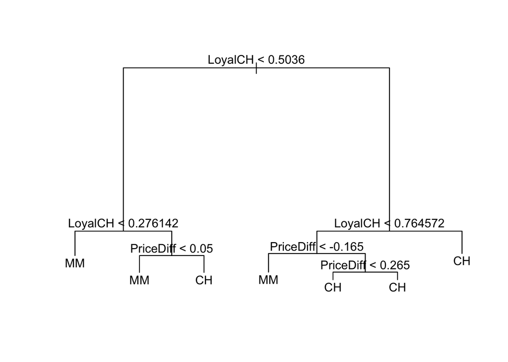

```r
plot(tree.oj)
text(tree.oj,pretty=0)
```

`LoyalCH` is the most imporant variable of the tree. Top 3 nodes contain `LoyalCH`

#### e

```r
oj.pred <- predict(tree.oj, OJ[test,],type="class") #classification
cm <- table(OJ[test,]$Purchase, oj.pred)
print(cm)
```

```
##     oj.pred
##       CH  MM
##   CH 152  19
##   MM  32  67
```

```r
accuracy <- sum(diag(cm))/sum(cm)
errorrate <- 1 - accuracy
errorrate
```

```
## [1] 0.1888889
```

#### f g

```r
cv.oj <- cv.tree(tree.oj, FUN=prune.tree)
print(cv.oj)
```

```
## $size
## [1] 7 6 5 4 3 2 1
##
## $dev
## [1]  697.7742  672.3676  721.1061  722.5296  785.2427  786.4040 1078.4624
##
## $k
## [1]      -Inf  14.33140  31.91234  35.17952  42.37864  46.23075 309.00727
##
## $method
## [1] "deviance"
##
## attr(,"class")
## [1] "prune"         "tree.sequence"
```

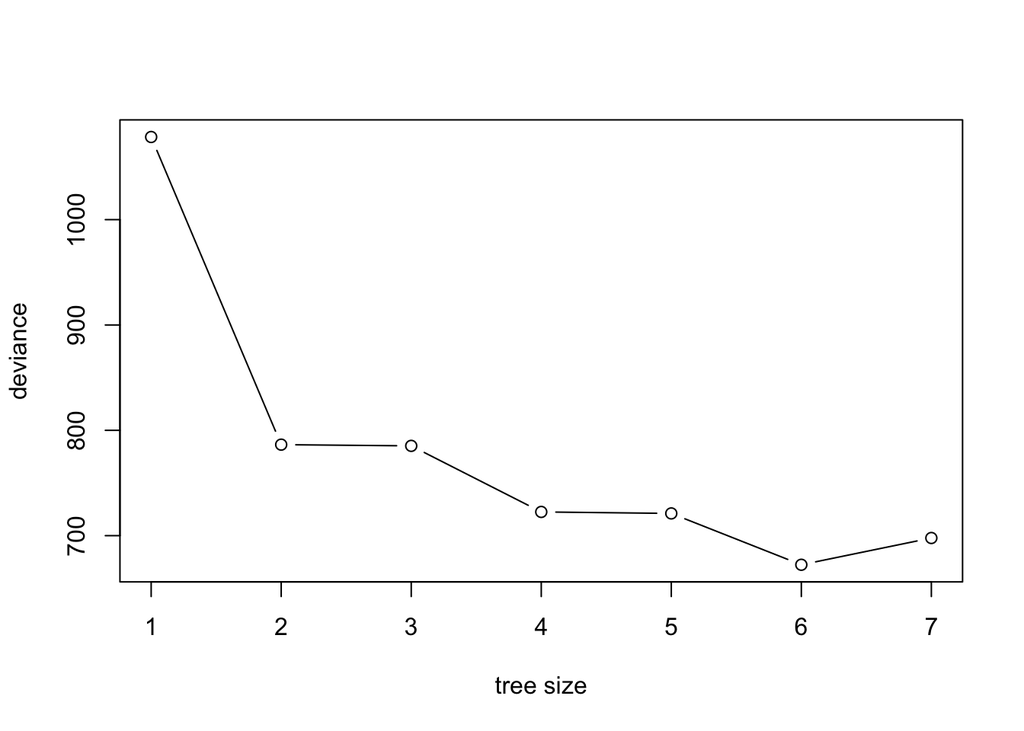

```r
#str(cv.oj)
plot(cv.oj$size, cv.oj$dev, type ="b", xlab = "tree size", ylab="deviance")
```

### h

Cross validation indicates that tree size = 6 has the lowest deviance

### i

```r
prune.oj <- prune.tree(tree.oj,best=6)
#plot(prune.oj)
```

### j

```r
summary(tree.oj)
```

```
##
## Classification tree:
## tree(formula = Purchase ~ ., data = OJ[train, ])
## Variables actually used in tree construction:
## [1] "LoyalCH"   "PriceDiff"
## Number of terminal nodes:  7
## Residual mean deviance:  0.7517 = 596.1 / 793
## Misclassification error rate: 0.155 = 124 / 800
```

```r
summary(prune.oj)
```

```
##
## Classification tree:
## snip.tree(tree = tree.oj, nodes = 13L)
## Variables actually used in tree construction:
## [1] "LoyalCH"   "PriceDiff"
## Number of terminal nodes:  6
## Residual mean deviance:  0.7689 = 610.5 / 794
## Misclassification error rate: 0.155 = 124 / 800
```

misclassification error is exactly the same between original and pruned tree

### k

```r
prune.oj.pred <- predict(prune.oj, OJ[test,],type="class") #classification
cmp <- table(OJ[test,]$Purchase, prune.oj.pred)
accuracy <- sum(diag(cmp))/sum(cmp)
errorrate <- 1 - accuracy
#for pruned
errorrate
```

```
## [1] 0.1888889
```

Test error rate are also the same between original and unpruned trees at 0.189

# Ex 10

```r
require(ISLR)
require(gbm)
data(Hiters)
```

#### a

```r
##clean data
sum(is.na(Hitters))
```

```
## [1] 59
```

```r
Hitters <- na.omit(Hitters) ## removing NAs
sum(is.na(Hitters))
```

```
## [1] 0
```

### b

```r
nfeats <- dim(Hitters)[2] -1
nsamp <-  dim(Hitters)[1]
train <- 1:200 #250 / 150 split
test <- (1:nsamp)[-train]
```

### c

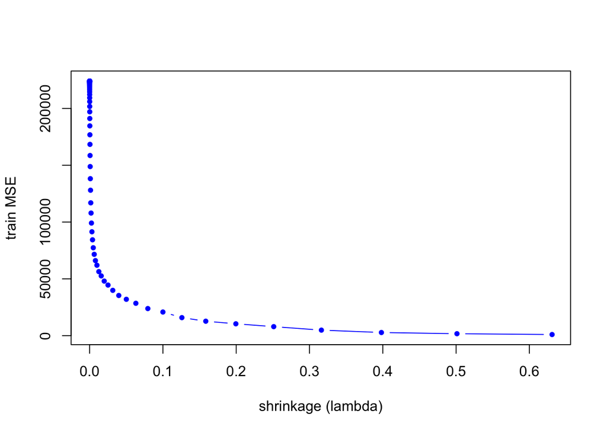

```r
set.seed(103)
pows = seq(-10, -0.2, by = 0.1)
lambdas = 10^pows
length.lambdas = length(lambdas)
train.errors = rep(NA, length.lambdas)
test.errors = rep(NA, length.lambdas)
for (i in 1:length.lambdas) {
  boost.hitters <- gbm(Salary ~ ., data=Hitters[train,] , distribution="gaussian",
                       n.trees=1000, shrinkage = lambdas[i], interaction.depth = 1)
  train.pred <- predict(boost.hitters, Hitters[train,], n.trees=1000 )
  test.pred <- predict(boost.hitters, Hitters[test,], n.trees=1000 )
  train.errors[i] <- mean( (Hitters[train,]$Salary - train.pred)^2  )
  test.errors[i] <- mean( (Hitters[test,]$Salary - test.pred)^2  )
}
#plotting
plot(lambdas, train.errors, type="b", xlab="shrinkage (lambda)", ylab = "train MSE", col="blue", pch=20)
```

### d

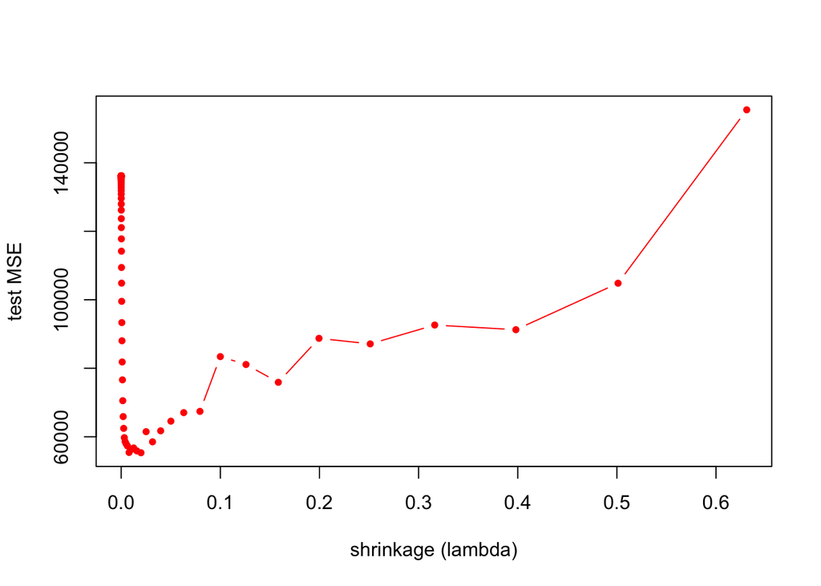

```r
plot(lambdas, test.errors, type="b", xlab="shrinkage (lambda)", ylab = "test MSE", col="red", pch=20)
```

```r
print(paste("boosting best test mse ", min(test.errors)))
```

```
## [1] "boosting best test mse  55336.9202937534"
```

```r
best_lambda <- lambdas[which.min(test.errors)]
best_lambda
```

```
## [1] 0.01995262
```

#### e

```r
## linear regression full model
lm.fit <- lm(Salary ~ ., data=Hitters[train,])
lm.pred <- predict(lm.fit, Hitters[test,])
lm.test.mse <- mean( (Hitters[test,]$Salary  - lm.pred)^2   )
print(paste("OLS test mse full model", lm.test.mse))
```

```
## [1] "OLS test mse full model 124815.152547457"
```

```r
### lasso
library(glmnet)
set.seed(134)
x <- model.matrix(Salary ~ . , data=Hitters[train,])
y <- Hitters[train,]$Salary
x.test <- model.matrix(Salary ~ . , data=Hitters[test,])
lasso.fit <- glmnet(x,y, alpha=1) #lasso
lasso.pred <- predict(lasso.fit, s=0.01, newx = x.test)
lasso.test.mse <- mean( (Hitters[test,]$Salary - lasso.pred)^2)
print(paste("lasso regularisation test mse", lasso.test.mse))
```

```
## [1] "lasso regularisation test mse 122285.000051318"
```

Linear regression and regularisation like lasso have higher test MSE then boosting almost by a factor of two

### f

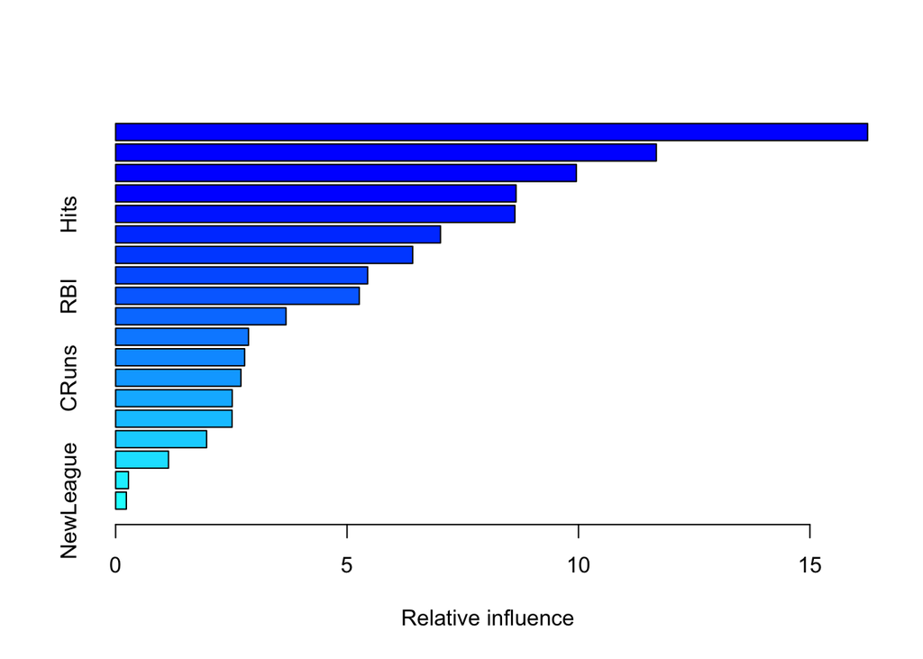

```
##                 var    rel.inf
## CHmRun       CHmRun 16.2464377
## Walks         Walks 11.6816442
## CAtBat       CAtBat  9.9537777
## Years         Years  8.6510975
## Hits           Hits  8.6259821
## CRBI           CRBI  7.0184910
## PutOuts     PutOuts  6.4172370
## CWalks       CWalks  5.4451756
## RBI             RBI  5.2644794
## CHits         CHits  3.6809891
## AtBat         AtBat  2.8699489
## HmRun         HmRun  2.7874174
## CRuns         CRuns  2.7066622
## Assists     Assists  2.5190996
## Errors       Errors  2.5151030
## Division   Division  1.9650221
## Runs           Runs  1.1423270
## League       League  0.2773784
## NewLeague NewLeague  0.2317301
```

```r
boost.best <-  gbm(Salary ~ ., data=Hitters[train,] , distribution="gaussian",
                       n.trees=1000, shrinkage = best_lambda, interaction.depth = 1)
summary(boost.best)
```

`CHmRun`, `Walks` and `CatBat` are the three most important variables.

### g

```r
require(randomForest)
bag.hitters <- randomForest(Salary~., data=Hitters[train,], mtry=nfeats, tree=500, importance=T) #m=p is a bagging
bag.pred <- predict(bag.hitters, Hitters[test,])
bag.test.mse <- mean( (Hitters[test,]$Salary - bag.pred)^2 )
print(paste("bagging test mse", bag.test.mse))
```

```
## [1] "bagging test mse 55494.4530906341"
```

Bagging test MSE is very similar to boosting test.mse

# Ex 11

```r
require(ISLR)
require(gbm)
data(Caravan)
```

#### a)

```r
nfeats <- dim(Caravan)[2] -1
nsam  <- dim(Caravan)[1]
train <- 1:1000
test <- (1:nsam)[-train]
Caravan$Purchase = ifelse(Caravan$Purchase == "Yes", 1, 0)
```

#### b)

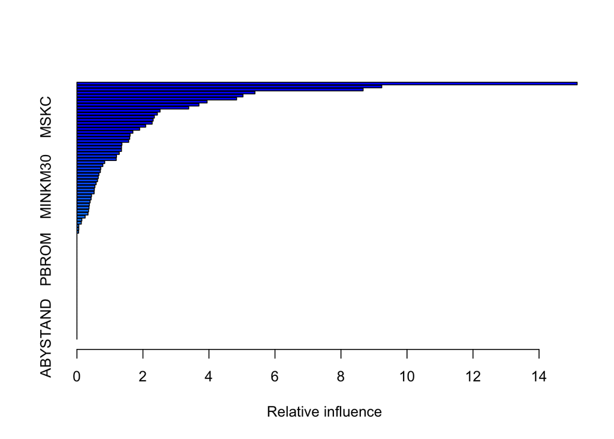

```
##               var     rel.inf
## PPERSAUT PPERSAUT 15.15534009
## MKOOPKLA MKOOPKLA  9.23499526
## MOPLHOOG MOPLHOOG  8.67017024
## MBERMIDD MBERMIDD  5.39403655
## MGODGE     MGODGE  5.03047673
## PBRAND     PBRAND  4.83740038
## MINK3045 MINK3045  3.94305387
## ABRAND     ABRAND  3.69692919
## MOSTYPE   MOSTYPE  3.38768960
## PWAPART   PWAPART  2.51970169
## MGODPR     MGODPR  2.43689096
## MSKC         MSKC  2.34594774
## MAUT2       MAUT2  2.30973409
## MFWEKIND MFWEKIND  2.27959503
## MBERARBG MBERARBG  2.08245286
## MSKA         MSKA  1.90020973
## PBYSTAND PBYSTAND  1.69481877
## MGODOV     MGODOV  1.61147668
## MAUT1       MAUT1  1.59879109
## MBERHOOG MBERHOOG  1.56791308
## MINK7512 MINK7512  1.36255296
## MSKB1       MSKB1  1.35071475
## MINKGEM   MINKGEM  1.34913011
## MRELGE     MRELGE  1.28204167
## MAUT0       MAUT0  1.19929798
## MHHUUR     MHHUUR  1.19158719
## MFGEKIND MFGEKIND  0.84203310
## MRELOV     MRELOV  0.78554535
## MZPART     MZPART  0.72191139
## MINK4575 MINK4575  0.70935967
## MSKB2       MSKB2  0.66694112
## APERSAUT APERSAUT  0.64644681
## MGODRK     MGODRK  0.62380797
## MSKD         MSKD  0.58168337
## MINKM30   MINKM30  0.54392696
## PMOTSCO   PMOTSCO  0.52708603
## MOPLMIDD MOPLMIDD  0.52091706
## MGEMOMV   MGEMOMV  0.44231264
## MZFONDS   MZFONDS  0.43037800
```

[output cut: 31 more lines]

```
## AMOTSCO   AMOTSCO  0.00000000
## AVRAAUT   AVRAAUT  0.00000000
## AAANHANG AAANHANG  0.00000000
## ATRACTOR ATRACTOR  0.00000000
## AWERKT     AWERKT  0.00000000
## ABROM       ABROM  0.00000000
## ALEVEN     ALEVEN  0.00000000
## APERSONG APERSONG  0.00000000
## AGEZONG   AGEZONG  0.00000000
## AWAOREG   AWAOREG  0.00000000
## AZEILPL   AZEILPL  0.00000000
## APLEZIER APLEZIER  0.00000000
## AFIETS     AFIETS  0.00000000
## AINBOED   AINBOED  0.00000000
## ABYSTAND ABYSTAND  0.00000000
```

```r
set.seed(342)
boost.fit <- gbm(Purchase ~ ., data=Caravan[train,], distribution="bernoulli",
                 n.trees=1000, shrinkage = 0.01)
summary(boost.fit)
```

```r
  boost.prob <- predict(boost.fit, Caravan[test,], n.trees=1000, type="response")
  boost.pred <-ifelse(boost.prob > 0.2, 1, 0)
  cm <- table(Caravan[test,]$Purchase, boost.pred)
  print(cm)
```

```
##    boost.pred
##        0    1
##   0 4396  137
##   1  255   34
```

```r
  ## proporton of predicted to purchase who actually purchased
  f_pred_purch <- cm[2,2] / sum(cm[,2])  #all predicted to purchase is sum(cm[,2])
  f_pred_purch
```

```
## [1] 0.1988304
```

About 20% of people predicted to make a purchase actually end up making one.

```r
logi.fit <- glm(Purchase ~ . ,  data=Caravan[train,], family=binomial )
logi.prob <- predict(logi.fit, Caravan[test,], type="response")
logi.pred <- ifelse(logi.prob > 0.2, 1, 0)
cm.logi <- table(Caravan[test,]$Purchase, logi.pred)
f_pred_purch <- cm.logi[2,2] / sum(cm.logi[,2])
f_pred_purch
```

```
## [1] 0.1421569
```

Log regression has a lower prediction rate compared to boosting

# Ex 12

```r
set.seed(1)
require(ISLR)
data(Smarket)
summary(Smarket)
```

```
##       Year           Lag1                Lag2
##  Min.   :2001   Min.   :-4.922000   Min.   :-4.922000
##  1st Qu.:2002   1st Qu.:-0.639500   1st Qu.:-0.639500
##  Median :2003   Median : 0.039000   Median : 0.039000
##  Mean   :2003   Mean   : 0.003834   Mean   : 0.003919
##  3rd Qu.:2004   3rd Qu.: 0.596750   3rd Qu.: 0.596750
##  Max.   :2005   Max.   : 5.733000   Max.   : 5.733000
##       Lag3                Lag4                Lag5
##  Min.   :-4.922000   Min.   :-4.922000   Min.   :-4.92200
##  1st Qu.:-0.640000   1st Qu.:-0.640000   1st Qu.:-0.64000
##  Median : 0.038500   Median : 0.038500   Median : 0.03850
##  Mean   : 0.001716   Mean   : 0.001636   Mean   : 0.00561
##  3rd Qu.: 0.596750   3rd Qu.: 0.596750   3rd Qu.: 0.59700
##  Max.   : 5.733000   Max.   : 5.733000   Max.   : 5.73300
##      Volume           Today           Direction
##  Min.   :0.3561   Min.   :-4.922000   Down:602
##  1st Qu.:1.2574   1st Qu.:-0.639500   Up  :648
##  Median :1.4229   Median : 0.038500
##  Mean   :1.4783   Mean   : 0.003138
##  3rd Qu.:1.6417   3rd Qu.: 0.596750
##  Max.   :3.1525   Max.   : 5.733000
```

```r
set.seed(1)
```

```r
nsamp <- dim(Smarket)[1]
train <- sample(1:nsamp, 2/3*nsamp)
test <- (1:nsamp)[-train]
```

## logistic regression

```r
glm.fit <- glm(Direction ~ . - Year - Today, data=Smarket[train,], family="binomial")
glm.prob <- predict(glm.fit, newdata=Smarket[test,], type="response")
glm.pred <- ifelse(glm.prob > 0.5, "Up", "Down")
cm <- table(glm.pred, Smarket[test,]$Direction)
print(cm)
```

```
##
## glm.pred Down  Up
##     Down  106 136
##     Up     77  98
```

```r
#test error
logi.test.err <- mean(glm.pred != Smarket[test,]$Direction)
logi.test.err
```

```
## [1] 0.5107914
```

## boosting

```r
library(gbm)
Smarket$BinomialDirection <- ifelse(Smarket$Direction == "Up", 1,0)

boost.fit <- gbm(BinomialDirection ~ . - Year - Today - Direction,data=Smarket[train,],
                 distribution="bernoulli", n.trees = 5000)
yhat.boost <- predict(boost.fit, newdata=Smarket[test,], n.trees=5000)
yhat.pred <- rep(0, length(yhat.boost))
yhat.pred[yhat.boost > 0.5] = 1

cm <- table(yhat.pred, Smarket[test,]$BinomialDirection)
print(cm)
```

```
##
## yhat.pred   0   1
##         0 179 232
##         1   4   2
```

```r
#test error
boost.test.err <- mean(yhat.pred != Smarket[test,]$BinomialDirection)
boost.test.err
```

```
## [1] 0.5659472
```

### bagging

```r
Smarket = Smarket[, !(names(Smarket) %in% c("BinomialDirection"))]
library(randomForest)

bag.fit <- randomForest(Direction ~ . - Year - Today, data=Smarket[train,], mtry=6 )
yhat.bag <- predict(bag.fit, newdata=Smarket[test,])
cm <- table(yhat.bag, Smarket[test,]$Direction)
print(cm)
```

```
##
## yhat.bag Down  Up
##     Down  102 119
##     Up     81 115
```

```r
bag.test.err <- mean(yhat.bag != Smarket[test,]$Direction)
print(bag.test.err)
```

```
## [1] 0.4796163
```

#### random forest

```r
rf.fit <- randomForest(Direction ~ . - Year - Today, data=Smarket[train,], mtry=2)
yhat.rf <- predict(rf.fit, newdata=Smarket[test,])
cm <- table(yhat.rf, Smarket[test,]$Direction)
print(cm)
```

```
##
## yhat.rf Down  Up
##    Down   98 115
##    Up     85 119
```

```r
rf.test.err <- mean(yhat.rf != Smarket[test,]$Direction)
print(rf.test.err)
```

```
## [1] 0.4796163
```

We observet that bagging and random forest has the lowest test error rate